# Simulation-Based Power Analysis

Part 6: Fully crossed design and by-item varying intercepts — Handout

Author

Affiliation

Filip Andras, David López-García & David Sánchez Casasola

Centro de Investigación Mente Cerebro y Comportamiento (CIMCYC), Universidad de Granada

Published

26 May 2026

# 1 Why by-item random intercepts?

So far we have modelled variability between **subjects**: some people are faster, some slower, some show a bigger lexical-frequency effect, others a smaller one.

But the **items** (the actual words in our LDT example) also come with their own variability. Words are sampled from a pool of possible items. Each word has its own baseline RT: *table* might be responded to consistently faster than *xylophone*, regardless of who is reading.

To make the simulation realistic, we add **by-item adjustments to the intercept**.

# 2 Fully crossed designs

A second important structural feature: in this example each word is seen by **every subject**. This is called a **fully crossed design**. Every (subject, item) cell of the design matrix has at least one observation.

Two consequences:

- The data are not independent in two different ways: responses to the same item are correlated (across subjects), and responses from the same subject are correlated (across items).
- A traditional analysis would have run two ANOVAs — one averaged over subjects (called $F_1$) and one averaged over items ($F_2$). Linear mixed models replace both with a single model that includes both sources of variability.

The LMM formula notation for the item random intercept is `(1 | item)`, exactly parallel to `(1 | subj)` for subjects.

# 3 Building the crossed design

We use `expand.grid()` to generate every combination of `item` and `subj`:

```r
n <- 20  # subjects
k <- 20  # 20 items per condition (so 40 items total)

# fully crossed design: each subject sees all items
sim_dat <- expand.grid(item = 1:(k * 2), subj = 1:n)

# assign items to conditions (first k items are high frequency, next k are low)
sim_dat$cond.cod <- rep(c(-0.5, 0.5), each = k)

head(sim_dat)
```

```
  item subj cond.cod
1    1    1     -0.5
2    2    1     -0.5
3    3    1     -0.5
4    4    1     -0.5
5    5    1     -0.5
6    6    1     -0.5
```

Sanity check — every subject sees every item exactly once:

```r
head(xtabs(~ subj + item, data = sim_dat))
```

```
    item
subj 1 2 3 4 5 6 7 8 9 10 11 12 13 14 15 16 17 18 19 20 21 22 23 24 25 26 27 28 29 30 31 32 33 34 35 36 37 38 39 40
   1 1 1 1 1 1 1 1 1 1  1  1  1  1  1  1  1  1  1  1  1  1  1  1  1  1  1  1  1  1  1  1  1  1  1  1  1  1  1  1  1
   2 1 1 1 1 1 1 1 1 1  1  1  1  1  1  1  1  1  1  1  1  1  1  1  1  1  1  1  1  1  1  1  1  1  1  1  1  1  1  1  1
   3 1 1 1 1 1 1 1 1 1  1  1  1  1  1  1  1  1  1  1  1  1  1  1  1  1  1  1  1  1  1  1  1  1  1  1  1  1  1  1  1
   4 1 1 1 1 1 1 1 1 1  1  1  1  1  1  1  1  1  1  1  1  1  1  1  1  1  1  1  1  1  1  1  1  1  1  1  1  1  1  1  1
   5 1 1 1 1 1 1 1 1 1  1  1  1  1  1  1  1  1  1  1  1  1  1  1  1  1  1  1  1  1  1  1  1  1  1  1  1  1  1  1  1
   6 1 1 1 1 1 1 1 1 1  1  1  1  1  1  1  1  1  1  1  1  1  1  1  1  1  1  1  1  1  1  1  1  1  1  1  1  1  1  1  1
```

Each cell contains a 1, confirming the fully crossed structure.

# 4 Generating by-item adjustments

By-item adjustments are drawn from a normal distribution centred on zero, the same way we did for subjects. A reasonable starting value is $\sigma_w = 100$:

```r
sigma_w <- 100   # SD of item random intercepts

# one adjustment per unique item:
w <- rnorm(n = length(unique(sim_dat$item)), mean = 0, sd = sigma_w)
w
```

```
 [1]  137.095845  -56.469817   36.312841   63.286260   40.426832  -10.612452  151.152200   -9.465904  201.842371
[10]   -6.271410  130.486965  228.664539 -138.886070  -27.878877  -13.332134   63.595040  -28.425292 -265.645542
[19] -244.046693  132.011335  -30.663859 -178.130843  -17.191736  121.467470  189.519346  -43.046913  -25.726938
[28] -176.316309   46.009735  -63.999488   45.545012   70.483734  103.510352  -60.892638   50.495512 -171.700868
[37]  -78.445901  -85.090759 -241.420765    3.612261
```

There is one value per item. We will look it up by item id during data generation, the same way we looked up subject adjustments in Part 4.

# 5 Extended generative formula

The full generative formula now includes both a subject and an item random intercept:

$$rt_{ij} = \beta_0 + u_{0i} + w_{0j} + (\beta_1 + u_{1i}) \times \text{cond.cod}_{ij} + \varepsilon_{ij}$$

with:

- $u_{0i} \sim \text{Normal}(0, \sigma_{u0})$ — by-subject intercept
- $u_{1i} \sim \text{Normal}(0, \sigma_{u1})$ — by-subject slope (correlated with $u_{0i}$)
- $w_{0j} \sim \text{Normal}(0, \sigma_w)$ — by-item intercept (the new term)
- $\varepsilon_{ij} \sim \text{Normal}(0, \sigma)$ — residual error

The model fits this with: `rt ~ cond.cod + (1 + cond.cod | subj) + (1 | item)`.

# 6 A function for the full crossed design

We extend Part 5’s generator one more time with the item random intercept:

```r
gendat_ldt_crossed <- function(n        = 20,    # subjects
                               k        = 20,    # items per condition
                               b0       = 725,   # grand mean
                               b1       = 50,    # frequency effect
                               sigma_u0 = 150,   # SD of subject intercepts
                               sigma_u1 = 20,    # SD of subject slopes
                               rho      = -0.5,  # correlation between subject intercepts and slopes
                               sigma_w  = 100,   # SD of item intercepts (new)
                               sigma    = 200) { # residual SD

  # fully crossed design
  sim_dat          <- expand.grid(item = 1:(k * 2), subj = 1:n)
  sim_dat$cond.cod <- rep(c(-0.5, 0.5), each = k)

  # subject random effects: correlated intercepts and slopes
  Sigma_u <- matrix(c(sigma_u0^2,                  rho * sigma_u0 * sigma_u1,
                      rho * sigma_u0 * sigma_u1,   sigma_u1^2),
                    nrow = 2)
  u <- mvrnorm(n     = length(unique(sim_dat$subj)),
               mu    = c(0, 0),
               Sigma = Sigma_u)

  # item random effects: intercepts only
  w <- rnorm(n = length(unique(sim_dat$item)), mean = 0, sd = sigma_w)

  # generate RTs row by row
  N  <- dim(sim_dat)[1]
  rt <- rep(NA, N)
  for (i in 1:N) {
    rt[i] <- rnorm(1,
                   b0 +
                   u[sim_dat[i, ]$subj, 1] +       # subject intercept
                   w[sim_dat[i, ]$item] +          # item intercept (new)
                   (b1 + u[sim_dat[i, ]$subj, 2]) * sim_dat[i, ]$cond.cod,
                   sigma)
  }

  sim_dat$rt   <- rt
  sim_dat$subj <- factor(sim_dat$subj)
  sim_dat$item <- factor(sim_dat$item)
  sim_dat
}
```

The two new lines compared to Part 5: the `rnorm()` call that generates `w`, and the `w[sim_dat[i, ]$item]` lookup inside the loop.

# 7 Testing the function

Generate one dataset and inspect its structure:

```r
sim_dat <- gendat_ldt_crossed(n = 20, k = 20)
dim(sim_dat) # 20 subjects x 40 items = 800 observations
```

```
[1] 800   4
```

```r
head(sim_dat, 41)
```

```
   item subj cond.cod        rt
1     1    1     -0.5  517.8648
2     2    1     -0.5  397.0241
3     3    1     -0.5  699.1036
4     4    1     -0.5  453.9017
5     5    1     -0.5  545.5217
6     6    1     -0.5  640.8671
7     7    1     -0.5  520.8708
8     8    1     -0.5  242.1079
9     9    1     -0.5  513.7042
10   10    1     -0.5  783.3997
11   11    1     -0.5  918.0549
12   12    1     -0.5  519.1263
13   13    1     -0.5  730.3666
14   14    1     -0.5 1029.0081
```

[output cut: 27 more lines]

## 7.1 Verifying the fully crossed structure

Each subject sees 20 items per condition:

```r
xtabs(~ subj + cond.cod, data = sim_dat)
```

```
    cond.cod
subj -0.5 0.5
  1    20  20
  2    20  20
  3    20  20
  4    20  20
  5    20  20
  6    20  20
  7    20  20
  8    20  20
  9    20  20
  10   20  20
  11   20  20
  12   20  20
  13   20  20
  14   20  20
  15   20  20
  16   20  20
  17   20  20
  18   20  20
  19   20  20
  20   20  20
```

Each item is responded to by all 20 subjects:

```r
xtabs(~ cond.cod + item, data = sim_dat)
```

```
        item
cond.cod  1  2  3  4  5  6  7  8  9 10 11 12 13 14 15 16 17 18 19 20 21 22 23 24 25 26 27 28 29 30 31 32 33 34 35 36 37
    -0.5 20 20 20 20 20 20 20 20 20 20 20 20 20 20 20 20 20 20 20 20  0  0  0  0  0  0  0  0  0  0  0  0  0  0  0  0  0
    0.5   0  0  0  0  0  0  0  0  0  0  0  0  0  0  0  0  0  0  0  0 20 20 20 20 20 20 20 20 20 20 20 20 20 20 20 20 20
        item
cond.cod 38 39 40
    -0.5  0  0  0
    0.5  20 20 20
```

Exactly one observation per (subject, item) pair:

```r
xtabs(~ subj + item, data = sim_dat)
```

```
    item
subj 1 2 3 4 5 6 7 8 9 10 11 12 13 14 15 16 17 18 19 20 21 22 23 24 25 26 27 28 29 30 31 32 33 34 35 36 37 38 39 40
  1  1 1 1 1 1 1 1 1 1  1  1  1  1  1  1  1  1  1  1  1  1  1  1  1  1  1  1  1  1  1  1  1  1  1  1  1  1  1  1  1
  2  1 1 1 1 1 1 1 1 1  1  1  1  1  1  1  1  1  1  1  1  1  1  1  1  1  1  1  1  1  1  1  1  1  1  1  1  1  1  1  1
  3  1 1 1 1 1 1 1 1 1  1  1  1  1  1  1  1  1  1  1  1  1  1  1  1  1  1  1  1  1  1  1  1  1  1  1  1  1  1  1  1
  4  1 1 1 1 1 1 1 1 1  1  1  1  1  1  1  1  1  1  1  1  1  1  1  1  1  1  1  1  1  1  1  1  1  1  1  1  1  1  1  1
  5  1 1 1 1 1 1 1 1 1  1  1  1  1  1  1  1  1  1  1  1  1  1  1  1  1  1  1  1  1  1  1  1  1  1  1  1  1  1  1  1
  6  1 1 1 1 1 1 1 1 1  1  1  1  1  1  1  1  1  1  1  1  1  1  1  1  1  1  1  1  1  1  1  1  1  1  1  1  1  1  1  1
  7  1 1 1 1 1 1 1 1 1  1  1  1  1  1  1  1  1  1  1  1  1  1  1  1  1  1  1  1  1  1  1  1  1  1  1  1  1  1  1  1
  8  1 1 1 1 1 1 1 1 1  1  1  1  1  1  1  1  1  1  1  1  1  1  1  1  1  1  1  1  1  1  1  1  1  1  1  1  1  1  1  1
  9  1 1 1 1 1 1 1 1 1  1  1  1  1  1  1  1  1  1  1  1  1  1  1  1  1  1  1  1  1  1  1  1  1  1  1  1  1  1  1  1
  10 1 1 1 1 1 1 1 1 1  1  1  1  1  1  1  1  1  1  1  1  1  1  1  1  1  1  1  1  1  1  1  1  1  1  1  1  1  1  1  1
  11 1 1 1 1 1 1 1 1 1  1  1  1  1  1  1  1  1  1  1  1  1  1  1  1  1  1  1  1  1  1  1  1  1  1  1  1  1  1  1  1
  12 1 1 1 1 1 1 1 1 1  1  1  1  1  1  1  1  1  1  1  1  1  1  1  1  1  1  1  1  1  1  1  1  1  1  1  1  1  1  1  1
  13 1 1 1 1 1 1 1 1 1  1  1  1  1  1  1  1  1  1  1  1  1  1  1  1  1  1  1  1  1  1  1  1  1  1  1  1  1  1  1  1
  14 1 1 1 1 1 1 1 1 1  1  1  1  1  1  1  1  1  1  1  1  1  1  1  1  1  1  1  1  1  1  1  1  1  1  1  1  1  1  1  1
  15 1 1 1 1 1 1 1 1 1  1  1  1  1  1  1  1  1  1  1  1  1  1  1  1  1  1  1  1  1  1  1  1  1  1  1  1  1  1  1  1
  16 1 1 1 1 1 1 1 1 1  1  1  1  1  1  1  1  1  1  1  1  1  1  1  1  1  1  1  1  1  1  1  1  1  1  1  1  1  1  1  1
  17 1 1 1 1 1 1 1 1 1  1  1  1  1  1  1  1  1  1  1  1  1  1  1  1  1  1  1  1  1  1  1  1  1  1  1  1  1  1  1  1
  18 1 1 1 1 1 1 1 1 1  1  1  1  1  1  1  1  1  1  1  1  1  1  1  1  1  1  1  1  1  1  1  1  1  1  1  1  1  1  1  1
  19 1 1 1 1 1 1 1 1 1  1  1  1  1  1  1  1  1  1  1  1  1  1  1  1  1  1  1  1  1  1  1  1  1  1  1  1  1  1  1  1
  20 1 1 1 1 1 1 1 1 1  1  1  1  1  1  1  1  1  1  1  1  1  1  1  1  1  1  1  1  1  1  1  1  1  1  1  1  1  1  1  1
```

# 8 What do the simulated RTs look like?

Generate a larger dataset (64 subjects, 40 items per condition) and plot the histogram:

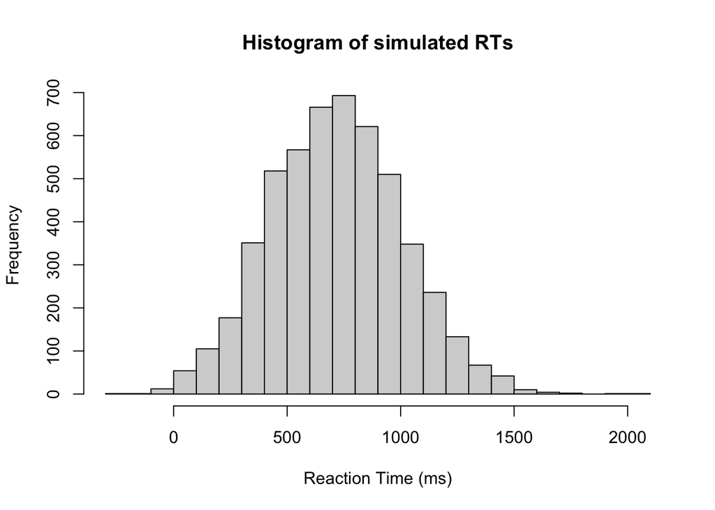

Figure 1: Histogram of simulated RTs from the fully crossed design. Notice the symmetric, normal-like distribution — which is unrealistic for real RT data.

```r
sim_dat <- gendat_ldt_crossed(n = 64, k = 40)
hist(sim_dat$rt, breaks = 30,
     main = "Histogram of simulated RTs",
     xlab = "Reaction Time (ms)")
```

**Warning**

**Look closely at the distribution.** It is roughly symmetric and bell-shaped. But real reaction times are **right-skewed** — there is a hard lower bound (motor response cannot be faster than ~150 ms) and a long right tail (occasional very slow trials).

The Gaussian generative process produces RTs that can even go *negative* for extreme outliers, which is impossible in reality. Part 7 fixes this by switching to a **log-normal** distribution for the RTs.

# 9 Summary and next step

In this part we:

- Added **by-item random intercepts** as a third random effect.
- Recognised that **fully crossed designs** carry dependency from both subjects and items, which is naturally handled by `(1 | subj) + (1 | item)` in the LMM.
- Extended the data-generating function to `gendat_ldt_crossed()` with $\sigma_w$ as a new parameter.
- Verified the design is fully crossed.
- Noted that Gaussian-generated RTs are unrealistically symmetric.

The current generative process is now:

$$rt_{ij} = \beta_0 + u_{0i} + w_{0j} + (\beta_1 + u_{1i}) \times \text{cond.cod}_{ij} + \varepsilon_{ij}$$

with $\varepsilon_{ij} \sim \text{Normal}(0, \sigma)$,

$$\begin{pmatrix} u_0 \\ u_1 \end{pmatrix} \sim \text{MVN} \left(
\begin{pmatrix} 0 \\ 0 \end{pmatrix}, \, \Sigma_u \right), \quad
\Sigma_u = \begin{pmatrix}
\sigma_{u0}^2 & \rho \, \sigma_{u0} \sigma_{u1} \\
\rho \, \sigma_{u0} \sigma_{u1} & \sigma_{u1}^2
\end{pmatrix},$$

and $w_0 \sim \text{Normal}(0, \sigma_w)$.

The next part of the course models **$\log(rt)$ instead of $rt$**, which both ensures positive reaction times and captures the right-skewed shape of real RT distributions.